# *Introduction to Tensorflow*

## *What is TensorFlow?*

[figure not shown]

*TensorFlow is an open source software library released in **2015 by Google** to make it easier for developers to design, build, and train deep learning models. TensorFlow originated as an internal library that Google developers used to build models in-house. Although TensorFlow is only one of several options available to developers, we choose to use it here because of its **thoughtful design and ease of use**.*

*At a high level, TensorFlow is a **Python library that allows users to express arbitrary computation as a graph of data flows**. **Nodes** in this graph represent **mathematical operations**, whereas **edges** represent **data that is communicated from one node to another**. Data in TensorFlow are represented as **tensors**, which are **multidimensional arrays**. Although this framework for thinking about computation is valuable in many different fields, TensorFlow is primarily used for deep learning in practice and research.*

*The libraries of transformations that are available through TensorFlow are **written as high-performance C++ binaries**. Python just directs traffic between the pieces, and **provides high-level programming abstractions** to hook them together.*

*TensorFlow **applications can be run on** most any target that’s convenient: **a local machine, a cluster in the cloud, iOS and Android devices, CPUs or GPUs**. If you use Google’s own cloud, you can run TensorFlow on Google’s **custom TensorFlow Processing Unit (TPU) silicon for further acceleration**. The resulting models created by TensorFlow, though, can be deployed on most any device where they will be used to serve predictions.*

*TensorFlow 2.0, released in October 2019* *, revamped the framework in many ways based on user feedback, to make it easier to work with (e.g., by using the relatively **simple Keras API** for model training) and more performant. Distributed training is easier to run thanks to a new API, and support for **TensorFlow Lite** makes it possible to deploy models on a greater variety of platforms.*

*TensorFlow Benefits*

*The single biggest benefit TensorFlow provides for machine learning development is **abstraction**. Instead of dealing with the nitty-gritty details of implementing algorithms, or figuring out proper ways to hitch the output of one function to the input of another, the developer can focus on the overall logic of the application. TensorFlow takes care of the details behind the scenes.*

*TensorFlow offers additional conveniences for developers who need to debug and gain introspection into TensorFlow apps. The eager execution mode lets you evaluate and modify each graph operation separately and transparently, instead of constructing the entire graph as a single opaque object and evaluating it all at once. The TensorBoard visualization suite lets you inspect and profile the way graphs run by way of an interactive, web-based dashboard.*

*TensorFlow vs. The Competition*

*TensorFlow competes with a slew of other machine learning frameworks. PyTorch, CNTK, and MXNet are three major frameworks that address many of the same needs.*

- *PyTorch* *, in addition to being built with Python, and has many other similarities to TensorFlow: hardware-accelerated components under the hood, a highly interactive development model that allows for design-as-you-go work, and many useful components already included. PyTorch is generally a better choice for fast development of projects that need to be up and running in a short time, but TensorFlow wins out for larger projects and more complex workflows.*
- *CNTK* *, the Microsoft Cognitive Toolkit, like TensorFlow uses a graph structure to describe dataflow, but focuses most on creating deep learning neural networks. CNTK handles many neural network jobs faster, and has a broader set of APIs (Python, C++, C#, Java). But CNTK isn’t currently as easy to learn or deploy as TensorFlow.*
- *Apache MXNet* *, adopted by Amazon as the premier deep learning framework on AWS, can scale almost linearly across multiple GPUs and multiple machines. It also supports a broad range of language APIs—Python, C++, Scala, R, JavaScript, Julia, Perl, Go—although its native APIs aren’t as pleasant to work with as TensorFlow’s.*

## *Installation*

*Create a New Environment*

`conda create -n tensorflow_env python=3.6.9`

*Activate the New Environment*

`conda activate tensorflow_env`

*Install Tensorflow*

`pip install tensorflow` *- This installs the latest version*

*Install Jupyter*

`pip install jupyter notebook`

*Install other libraries*

*To Deactivate*

`conda deactivate`

```python
import tensorflow as tf

print("TensorFlow version: {}".format(tf.__version__))
print("Keras version: {}".format(tf.keras.__version__))
```

```
TensorFlow version: 2.3.0
Keras version: 2.4.0
```

*Tensorflow 1.x is built on the following core ideas:*

- *All the operations are performed within a Session Block.*
- *Global Variable initialization to be done.*

*Tensorflow 2.x is built on the following core ideas:*

- *The coding is more **pythonic**, so that users can get the results immediately like they are programming in numpy*
- *Retaining the characteristics of static graphs (for performance, distributed, and production deployment), this makes TensorFlow **fast, scalable, and ready for production**.*
- *Using **Keras as a high-level API** for deep learning, making Tensorflow easy to use and efficient*
- *Make the entire framework both high-level features (easy to use, efficient, and not flexible) and low-level features (powerful and scalable, not easy to use, but very flexible)*
- *Eager execution* *is by default in TensorFlow 2.0 and, it needs no special setup. The following below code can be used to find out whether a CPU or GPU is in use*

*Eager execution is a flexible machine learning platform for research and experimentation, providing:*

*TensorFlow's eager execution is an imperative programming environment that evaluates operations immediately, without building graphs: operations return concrete values instead of constructing a computational graph to run later.*

- *An **intuitive interface**—Structure your code naturally and use Python data structures. Quickly iterate on small models and small data.*
- *Easier debugging* *—Call ops directly to inspect running models and test changes. Use standard Python debugging tools for immediate error reporting.*
- *Natural control flow* *—Use Python control flow instead of graph control flow, simplifying the specification of dynamic models.*
- *Eager execution supports most TensorFlow operations and GPU acceleration.*

```python
variable = tf.Variable([3, 3])

if tf.test.is_gpu_available():
    print('GPU')
else:
    print('CPU')
```

```
WARNING:tensorflow:From <ipython-input-2-3731612c7d28>:3: is_gpu_available (from tensorflow.python.framework.test_util) is deprecated and will be removed in a future version.
Instructions for updating:
Use `tf.config.list_physical_devices('GPU')` instead.
GPU
```

## *TensorFlow Architecture*

*Tensorflow architecture works in three parts:*

- *Preprocessing the data*
- *Build the model*
- *Train and estimate the model*

*It is called Tensorflow because it takes input as a multi-dimensional array, also known as tensors. You can construct a sort of flowchart of operations (called a Graph) that you want to perform on that input. The input goes in at one end, and then it flows through this system of multiple operations and comes out the other end as output.*

*This is why it is called TensorFlow because the tensor goes in it flows through a list of operations, and then it comes out the other side.*

## *Tensorflow Basics*

### *Tensor*

*Tensorflow's name is directly derived from its core framework: **Tensor**. In Tensorflow, all the computations involve tensors. **A tensor is a vector or matrix of n-dimensions that represents all types of data.** All values in a tensor hold identical data type with a known (or partially known) shape. **The shape of the data is the dimensionality of the matrix or array**.*

*A tensor can be originated from the input data or the result of a computation. In TensorFlow, all the operations are conducted inside a graph. The graph is a set of computation that takes place successively. Each operation is called an op node and are connected to each other.*

*The graph outlines the ops and connections between the nodes. However, it does not display the values. The edge of the nodes is the tensor, i.e., a way to populate the operation with data.*

### *Graphs*

*TensorFlow makes use of a graph framework. **The graph gathers and describes all the series computations done during the training.** The graph has lots of advantages:*

- *It was done to run on multiple CPUs or GPUs and even mobile operating system*
- *The portability of the graph allows to preserve the computations for immediate or later use. The graph can be saved to be executed in the future.*
- *All the computations in the graph are done by connecting tensors together*
- *A tensor has a node and an edge* *. The node carries the mathematical operation and produces an endpoints outputs. The edges the edges explain the input/output relationships between nodes.*

### *Data Input Elements*

*In TensorFlow, however, data can be stored and manipulated using three different programming elements:*

- *Constants*

*Constants are parameters with values that do not change. To define a constant, we use **tf.constant()** command.*

- *Variables*

*Variables are created and tracked via the tf.Variable class. A **tf.Variable()** represents a tensor whose value can be changed by running ops on it. Specific ops allow you to read and modify the values of this tensor. Higher level libraries like tf.keras use tf.Variable to store model parameters.*

- *Placeholders*

_With **tf.placeholder()** you don't have to provide an initial value and you can specify it at run time with the **feed_dict** argument inside **Session.run** whereas in **tf.Variable** you can to provide initial value when you declare it._

## *Touchbase on TF 1.x*

*There were total 15 releases under tensorflow 1.x version. Below are few examples of how tensorflow 1.x functions:*

```python
# Downgrading Tesnorflow
!pip install tensorflow==1.14.0
```

```python
import tensorflow as tf
print(tf.__version__)
```

```
1.14.0
```

### *Session*

*TensorFlow’s API is built around the idea of a computational graph, a way of visualizing a mathematical process.*

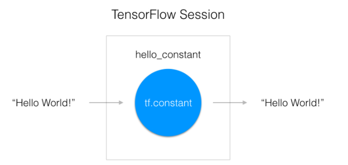

*A "**TensorFlow Session**", as shown above, is an environment for running a graph. The session is **in charge of allocating the operations to GPU(s) and/or CPU(s), including remote machines**.*

```python
hello_constant = tf.constant('Hello World!')
hello_constant
```

```
<tf.Tensor 'Const:0' shape=() dtype=string>
```

```python
# Create TensorFlow object called tensor
hello_constant = tf.constant('Hello World!')

# To Print value
with tf.Session() as sess:
        # Run the tf.constant operation in the session
        output = sess.run(hello_constant)
        print(output)
```

```
b'Hello World!'
```

_The code has already created the tensor, `hello_constant`, from the previous lines. The next step is to evaluate the tensor in a session._

*The code creates a session instance, `sess`, using `tf.Session`. The `sess.run()` function then evaluates the tensor and returns the results.*

```python
# A is a 0-dimensional int32 tensor
A = tf.constant(1234)

# B is a 1-dimensional int32 tensor
B = tf.constant([123,456,789])

# C is a 2-dimensional int32 tensor
C = tf.constant([ [123,456,789], [222,333,444] ])
```

```python
C
```

```
<tf.Tensor 'Const_4:0' shape=(2, 3) dtype=int32>
```

```python
x = tf.placeholder(tf.string)

with tf.Session() as sess:
    output = sess.run(x, feed_dict={x: 'Hello, world'})
    print(output)
```

```
Hello, world
```

_Use the feed_dict parameter in `tf.session.run()` to set the placeholder tensor. The above example shows the tensor `x` being set to the string `"Hello, world"`. It's also possible to set more than one tensor using `feed_dict` as shown below:_

```python
x = tf.placeholder(tf.string)
y = tf.placeholder(tf.int32)
z = tf.placeholder(tf.float32)

with tf.Session() as sess:
    output_x = sess.run(x,feed_dict={x: 'Test String', y: 123, z: 45.67})
    output_y = sess.run(y, feed_dict={x: 'Test String', y: 123, z:45.67})
    print(output_x)
    print(output_y)
```

```
Test String
123
```

_**Note**: If the data passed to the `feed_dict` doesn’t match the tensor type and can’t be cast into the tensor type, you’ll get the error `“ValueError: invalid literal for...”`._

### *TensorFlow Math Functions*

_Getting the input is great, but now you need to use it. We're going to use basic math functions that everyone knows and loves - add, subtract, multiply, and divide - with tensors. (There's many more math functions you can check out in the [documentation](https://www.tensorflow.org/versions/r1.15/api_docs/python/tf/math).)_

```python
x = tf.add(5, 2)  # 7

with tf.Session() as sess:
    output = sess.run(x)
    print(output)
```

```
7
```

```python
x = tf.subtract(10, 4) # 6
y = tf.multiply(2, 5)  # 10
```

*The `x` tensor will evaluate to `6`, because `10 - 4 = 6`. The `y` tensor will evaluate to `10`, because `2 * 5 = 10`. That was easy!*

### *Converting Types*

*It may be necessary to convert between types to make certain operators work together. For example, if you tried the following, it would fail with an exception:*

```python
tf.subtract(tf.constant(2.0),tf.constant(1))
```

[output not shown]

*That's because the constant `1` is an integer but the constant `2.0` is a floating point value and subtract expects them to match.*

*In cases like these, you can either make sure your data is all of the same type, or you can cast a value to another type. In this case, converting the `2.0` to an integer before subtracting, like so, will give the correct result:*

```python
c = tf.subtract(tf.cast(tf.constant(2.0), tf.int32), tf.constant(1))   # 1

with tf.Session() as sess:
    output = sess.run(c)
    print(output)
```

```
1
```

### *TensorFlow Linear Functions*

*The most common operation in neural networks is calculating the linear combination of inputs, weights, and biases. As a reminder, we can write the output of the linear operation as:*

[figure not shown]

*Here, **W** is a matrix of the weights connecting two layers. The output **y**, the input **x**, and the biases **b** are all vectors.*

#### *Weights and Bias in TensorFlow*

*The goal of training a neural network is to modify weights and biases to best predict the labels. In order to use weights and bias, you'll need a Tensor that can be modified. This leaves out `tf.placeholder()` and `tf.constant()`, since those Tensors can't be modified. This is where `tf.Variable` class comes in. Therefore, we use **tf.Variable()**.*

```python
x = tf.Variable(5)
```

_The `tf.Variable` class creates a tensor with an initial value that can be modified, much like a normal Python variable. This tensor stores its state in the session, so you must initialize the state of the tensor manually. You'll use the `tf.global_variables_initializer()` function to initialize the state of all the Variable tensors:_

```python
init = tf.global_variables_initializer()

with tf.Session() as sess:
    sess.run(init)
```

_The `tf.global_variables_initializer()` call returns an operation that will initialize all TensorFlow variables from the graph. You call the operation using a session to initialize all the variables as shown above. Using the `tf.Variable` class allows us to change the weights and bias, but an initial value needs to be chosen._

*Initializing the weights with random numbers from a normal distribution is good practice. Randomizing the weights helps the model from becoming stuck in the same place every time you train it. You'll learn more about this in the next lesson, gradient descent.*

_Similarly, choosing weights from a normal distribution prevents any one weight from overwhelming other weights. We'll use the `tf.truncated_normal()` function to generate random numbers from a normal distribution._

```python
n_features = 10
n_labels = 5

weights = tf.Variable(tf.truncated_normal((n_features, n_labels)))

init = tf.global_variables_initializer()

weights
```

```
<tf.Variable 'Variable_3:0' shape=(10, 5) dtype=float32_ref>
```

```python
with tf.Session() as sess:
    sess.run(init)
    output = sess.run(weights)
    print(output)
```

```
[[ 0.60160625  1.9877367   0.7216744   1.8937731   0.5498547 ]
 [-0.61505747  0.36898687  0.4345643   0.5682314  -0.19050802]
 [ 0.23256564  1.1835843   1.4556563   0.5592488  -0.3638788 ]
 [ 1.9384117   1.9215139   0.3922355   1.8087919   0.15078051]
 [-0.29640466  1.4494509  -0.7459172   0.09365788 -0.16632073]
 [-0.4862037   0.3769595  -0.54166925 -0.07328258 -0.6175938 ]
 [ 0.6746127  -1.3245162  -1.5296063   0.0903019   1.7478472 ]
 [ 1.031866    1.327255   -0.2787424   0.1869711   0.5185952 ]
 [ 1.249554    0.19225498 -0.5253551   0.5505299  -0.38776517]
 [ 0.77407354 -1.3665483  -0.516655    0.77079993  1.3562429 ]]
```

_The `tf.truncated_normal()` function returns a tensor with random values from a normal distribution whose magnitude is no more than 2 standard deviations from the mean._

*Since the weights are already helping prevent the model from getting stuck, you don't need to randomize the bias. Let's use the simplest solution, setting the bias to 0.*

```python
n_labels = 5
bias = tf.Variable(tf.zeros(n_labels))
```

*The `tf.zeros()` function returns a tensor with all zeros.*

### *TensorFlow Softmax*

*The softmax function squashes it's inputs, typically called **logits** or **logit scores**, to be between 0 and 1 and also normalizes the outputs such that they all sum to 1. This means the output of the softmax function is equivalent to a categorical probability distribution. It's the perfect function to use as the output activation for a network predicting multiple classes.*

[figure not shown]

*We're using TensorFlow to build neural networks and, appropriately, there's a function for calculating softmax.*

```python
x = tf.nn.softmax([2.0, 1.0, 0.2])
```

*Easy as that! `tf.nn.softmax()` implements the softmax function for you. It takes in logits and returns softmax activations.*

```python
def softmax_example():
    output = None
    logit_data = [19,354,354,45,354,54]
    logits = tf.placeholder(tf.float32)

    # Calculate the softmax of the logits
    softmax = tf.nn.softmax(logits)

    with tf.Session() as sess:
        # Feed in the logit data
        output = sess.run(softmax, feed_dict={logits: logit_data})

    return output

print(softmax_example())
```

```
[0.         0.33333334 0.33333334 0.         0.33333334 0.        ]
```

### *TensorFlow Cross Entropy*

*Cross entropy is the cost function for classification with one-hot encoded labels.*

[figure not shown]

*To create a cross entropy function in TensorFlow, you'll need to use two new functions:*

- `tf.reduce_sum()`
- `tf.log()`

```python
x = tf.reduce_sum([1, 2, 3, 4, 5])  # 15
```

_The `tf.reduce_sum()` function takes an array of numbers and sums them together._

```python
l = tf.log(100.0)  # 4.60517
```

*This function does exactly what you would expect it to do. `tf.log()` takes the natural log of a number.*

```python
# print the cross entropy using `softmax_data` and `one_hot_encod_label`.

softmax_data = [0.7, 0.2, 0.1]
one_hot_data = [1.0, 0.0, 0.0]

softmax = tf.placeholder(tf.float32)
one_hot = tf.placeholder(tf.float32)

# Print cross entropy from session
cross_entropy = -tf.reduce_sum(tf.multiply(one_hot, tf.log(softmax)))

with tf.Session() as session:
    output = session.run(cross_entropy, feed_dict={one_hot: one_hot_data, softmax: softmax_data})
    print(output)
```

```
0.35667497
```